# Amazon Copurchased

This is a Python notebook created using "jupyter".

Author: Rafael J. P. dos Santos

## Condições do experimento

- Utilização de todas as features
- Limite de 22934 ligações (~10% da base)

## Parameters

We use the parameter below to set the maximum number of edges to be read from the CSV containing edges (links).

```python
max_edges = 22934 # Set quantity to read from file
edges_csv_file = "data/20180812_links"
nodes_csv_file = "data/20180812_nodes"
```

## Load the libraries

Let's load the Python libraries that we will need throughout the script

```python
import networkx as nx
import matplotlib.pyplot as plt
import pandas as pd
from sklearn.model_selection import train_test_split
import numpy as np
from sklearn.tree import export_graphviz
import pydot
from sklearn.ensemble import RandomForestRegressor
from __future__ import division
import sklearn
#from sklearn.cross_validation import cross_val_score
from sklearn.model_selection import cross_validate
from sklearn.metrics import make_scorer
import hashlib
import sys
print('The scikit-learn version is {}.'.format(sklearn.__version__))
```

```
The scikit-learn version is 0.20.2.
```

## Read graph

### Read only first lines of datafile

Due to slowness in calculating centrality measures, we use the parameter provided in the beggining of the script to limit the number of edges we will read.

```python
lines = []
total_line_count = 0
with open(edges_csv_file, 'rb') as f:
    f.readline()   # skip first line / header
    while True:
        line = f.readline()
        if not line:
            break
        if not (max_edges > 0 and len(lines) >= max_edges):
            lines.append(line)
        total_line_count += 1
G = nx.parse_edgelist(lines, delimiter=',', nodetype=int)
```

```python
print "Using %d edges out of %d available (%.2f%% of data)" % (len(lines), total_line_count, len(lines)/total_line_count * 100)
```

```
Using 22934 edges out of 229338 available (10.00% of data)
```

### Calculate nodes centrality measures

Now that we have our NetworkX graph, let's calculate some centrality measures for every node.

```python
centrality_measures = {}
```

#### Degree

```python
centrality_measures["degree"] = nx.degree(G)
```

#### Eigenvector centrality

```python
centrality_measures["eigenvector_centrality"] = nx.eigenvector_centrality_numpy(G)
```

#### Approximate betweenness centrality (current flow)

```python
centrality_measures["betweenness_centrality"] = nx.approximate_current_flow_betweenness_centrality(G)
```

#### Closeness centrality

```python
# Very slow!
centrality_measures["closeness_centrality"] = nx.closeness_centrality(G)
```

#### Betweenness centrality

```python
# Very slow!
centrality_measures["betweenness_centrality"] = nx.betweenness_centrality(G)
```

### Load node properties

Let's load the CSV containing the nodes data (title, price) into a Pandas dataframe, and append the centrality measures calculated above.

```python
df = pd.read_csv(nodes_csv_file)
```

#### Convert ID to random int to avoid leaking knowledge

```python
sha256_ids = df['id'].map(lambda x: int(hashlib.sha256(str(x)).hexdigest()[0:8], 16))
```

```python
# Add columns to dataframe
def merge_columns(dataframe, data):
    df = dataframe.copy()
    for col in data:
        rows = []
        for item in data[col].items():
            rows.append({"id": item[0], col: item[1]})
        df = df.merge(pd.DataFrame(rows))
    return df

df = merge_columns(df, centrality_measures)
df = merge_columns(df, {'sha256_id': sha256_ids})
```

### Let's convert some fields to numeric

```python
categorical_features = [
    'category1',
    'category2',
    'category3',
    'category4',
    'category5',
    'category6',
    'category7',
    'category8',
    'category9',
    'category10',
    'language',
    'coverType',
    'publisher',
    'rankingCategory',
    'authors'
]

numeric_features = [
    'degree',
    'eigenvector_centrality',
    'betweenness_centrality',
    'ranking',
    'reviewCount',
    'pages',
    'weight',
    'height',
    'width',
    'depth',
    'rating'
]

df = df.replace("<<MISSING_DATA>>", np.NaN)
df[numeric_features] = df[numeric_features].apply(pd.to_numeric)
df[['price']] = df[['price']].apply(pd.to_numeric)

for feature in numeric_features:
    df[feature].fillna(df[feature].mean(), inplace = True)
```

### Remove nodes without price

```python
df = df.drop(df[df["price"].isnull()].index)
#df = df.drop(df[df["price"] > 500].index)
```

### Inspect columns

```python
df.columns
```

```
Index([u'id', u'title', u'url', u'authors', u'coverType', u'publisher',
       u'edition', u'publicationDate', u'rankingCategory', u'category1',
       u'category2', u'category3', u'category4', u'category5', u'category6',
       u'category7', u'category8', u'category9', u'category10', u'isbn10',
       u'isbn13', u'language', u'postProcessed', u'price', u'ranking',
       u'pages', u'reviewCount', u'rating', u'width', u'height', u'depth',
       u'weight', u'eigenvector_centrality', u'degree',
       u'betweenness_centrality', u'sha256_id'],
      dtype='object')
```

### Features summary

Below we have a summary of the Pandas dataframe. We can see the number of nodes that we are actually analyzing, which depends on the max_edges parameter defined before.

```python
pd.set_option('display.max_columns', None)
#df.describe(include='all')
df.describe(include='all', percentiles=[0.25, 0.5, 0.75, 0.85, 0.9, 0.95, 0.99])
```

|  | id | title | url | authors | coverType | publisher | edition | publicationDate | rankingCategory | category1 | category2 | category3 | category4 | category5 | category6 | category7 | category8 | category9 | category10 | isbn10 | isbn13 | language | postProcessed | price | ranking | pages | reviewCount | rating | width | … |
| --- | --- | --- | --- | --- | --- | --- | --- | --- | --- | --- | --- | --- | --- | --- | --- | --- | --- | --- | --- | --- | --- | --- | --- | --- | --- | --- | --- | --- | --- | --- |
| count | 4907.000000 | 4907 | 4907 | 4907 | 4857 | 4862 | 0.0 | 444 | 4645 | 4589 | 4589 | 3384 | 1642 | 623 | 130 | 10 | 0.0 | 0.0 | 0.0 | 4864 | 4864 | 4862 | 4907.0 | 4907.000000 | 4907.000000 | 4907.000000 | 4907.000000 | 4907.000000 | 4907.000000 | … |
| unique | NaN | 4810 | 4907 | 3468 | 9 | 476 | NaN | 369 | 1 | 1 | 28 | 191 | 338 | 177 | 49 | 5 | NaN | NaN | NaN | 4864 | 4864 | 6 | NaN | NaN | NaN | NaN | NaN | NaN | NaN | … |
| top | NaN | Macroeconomia | https://www.amazon.com.br/dp/8535931015/ | Vários Autores (Autor) | Capa comum | Companhia das Letras | NaN | 5 de fevereiro de 2014 | Livros | Livros | Literatura e Ficção | Filosofia | Matemática | Faculdade | Probabilidade e Estatística | Neurociência | NaN | NaN | NaN | 8525431494 | 978-8521318378 | Português | NaN | NaN | NaN | NaN | NaN | NaN | NaN | … |
| freq | NaN | 5 | 1 | 51 | 3996 | 385 | NaN | 5 | 4645 | 4589 | 769 | 375 | 141 | 41 | 14 | 3 | NaN | NaN | NaN | 1 | 1 | 4163 | NaN | NaN | NaN | NaN | NaN | NaN | NaN | … |
| mean | 3225.416548 | NaN | NaN | NaN | NaN | NaN | NaN | NaN | NaN | NaN | NaN | NaN | NaN | NaN | NaN | NaN | NaN | NaN | NaN | NaN | NaN | NaN | 1.0 | 80.941406 | 33031.893750 | 369.227378 | 17.930282 | 4.434880 | 15.247541 | … |
| std | 2171.402172 | NaN | NaN | NaN | NaN | NaN | NaN | NaN | NaN | NaN | NaN | NaN | NaN | NaN | NaN | NaN | NaN | NaN | NaN | NaN | NaN | NaN | 0.0 | 175.628354 | 53225.905364 | 264.703081 | 38.474234 | 0.530239 | 2.424275 | … |
| min | 1.000000 | NaN | NaN | NaN | NaN | NaN | NaN | NaN | NaN | NaN | NaN | NaN | NaN | NaN | NaN | NaN | NaN | NaN | NaN | NaN | NaN | NaN | 1.0 | 2.900000 | 3.000000 | 4.000000 | 1.000000 | 1.000000 | 1.800000 | … |
| 25% | 1407.500000 | NaN | NaN | NaN | NaN | NaN | NaN | NaN | NaN | NaN | NaN | NaN | NaN | NaN | NaN | NaN | NaN | NaN | NaN | NaN | NaN | NaN | 1.0 | 25.900000 | 5194.000000 | 208.000000 | 3.000000 | 4.300000 | 13.800000 | … |
| 50% | 3108.000000 | NaN | NaN | NaN | NaN | NaN | NaN | NaN | NaN | NaN | NaN | NaN | NaN | NaN | NaN | NaN | NaN | NaN | NaN | NaN | NaN | NaN | 1.0 | 37.870000 | 16708.000000 | 312.000000 | 10.000000 | 4.437158 | 15.400000 | … |
| 75% | 4593.500000 | NaN | NaN | NaN | NaN | NaN | NaN | NaN | NaN | NaN | NaN | NaN | NaN | NaN | NaN | NaN | NaN | NaN | NaN | NaN | NaN | NaN | 1.0 | 60.310000 | 35350.500000 | 448.000000 | 17.864682 | 4.800000 | 16.000000 | … |
| 85% | 5221.300000 | NaN | NaN | NaN | NaN | NaN | NaN | NaN | NaN | NaN | NaN | NaN | NaN | NaN | NaN | NaN | NaN | NaN | NaN | NaN | NaN | NaN | 1.0 | 94.837000 | 54402.400000 | 560.000000 | 18.000000 | 5.000000 | 16.800000 | … |
| 90% | 5763.400000 | NaN | NaN | NaN | NaN | NaN | NaN | NaN | NaN | NaN | NaN | NaN | NaN | NaN | NaN | NaN | NaN | NaN | NaN | NaN | NaN | NaN | 1.0 | 136.180000 | 72044.200000 | 648.000000 | 28.000000 | 5.000000 | 18.000000 | … |
| 95% | 7665.700000 | NaN | NaN | NaN | NaN | NaN | NaN | NaN | NaN | NaN | NaN | NaN | NaN | NaN | NaN | NaN | NaN | NaN | NaN | NaN | NaN | NaN | 1.0 | 274.099000 | 115962.100000 | 816.000000 | 59.000000 | 5.000000 | 20.600000 | … |
| 99% | 9206.760000 | NaN | NaN | NaN | NaN | NaN | NaN | NaN | NaN | NaN | NaN | NaN | NaN | NaN | NaN | NaN | NaN | NaN | NaN | NaN | NaN | NaN | 1.0 | 932.993800 | 308666.140000 | 1249.880000 | 173.000000 | 5.000000 | 21.900000 | … |
| max | 9738.000000 | NaN | NaN | NaN | NaN | NaN | NaN | NaN | NaN | NaN | NaN | NaN | NaN | NaN | NaN | NaN | NaN | NaN | NaN | NaN | NaN | NaN | 1.0 | 2531.070000 | 433962.000000 | 4804.000000 | 755.000000 | 5.000000 | 30.400000 | … |

Below we can inspect the first rows of data, containing title, price, degree and other centrality measures.

```python
df.head(10)
```

|  | id | title | url | authors | coverType | publisher | edition | publicationDate | rankingCategory | category1 | category2 | category3 | category4 | category5 | category6 | category7 | category8 | category9 | category10 | isbn10 | isbn13 | language | postProcessed | price | ranking | pages | reviewCount | rating | width | … |
| --- | --- | --- | --- | --- | --- | --- | --- | --- | --- | --- | --- | --- | --- | --- | --- | --- | --- | --- | --- | --- | --- | --- | --- | --- | --- | --- | --- | --- | --- | --- |
| 0 | 1 | The Stanford Mathematics Problem Book: With Hi... | https://www.amazon.com.br/dp/0486469247/ | George Polya (Autor), | Capa comum | Dover Publications | NaN | 19 de fevereiro de 2009 | Livros | Livros | Inglês e Outras Línguas | Ciências Tecnológicas | Matemática | Estudo e Ensino | NaN | NaN | NaN | NaN | NaN | 0486469247 | 978-0486469249 | Inglês | 1 | 26.25 | 59183.0 | 68.0 | 1.000000 | 4.000000 | 14.0 | … |
| 1 | 2 | Fourier Series | https://www.amazon.com.br/dp/0486633179/ | Georgi P. Tolstov (Autor), | Capa comum | Dover Publications | NaN | 1 de junho de 1976 | Livros | Livros | Inglês e Outras Línguas | Ciências Tecnológicas | Matemática | Aplicada | Probabilidade e Estatística | NaN | NaN | NaN | NaN | 0486633179 | 978-0486633176 | Inglês | 1 | 50.37 | 56112.0 | 352.0 | 3.000000 | 4.600000 | 14.6 | … |
| 2 | 3 | Probability Theory: A Concise Course | https://www.amazon.com.br/dp/0486635449/ | Y. A. Rozanov (Autor), | Capa comum | Dover Publications | NaN | NaN | Livros | Livros | Inglês e Outras Línguas | Ciências Tecnológicas | Matemática | Aplicada | Probabilidade e Estatística | NaN | NaN | NaN | NaN | 0486635449 | 978-0486635446 | Inglês | 1 | 29.23 | 44345.0 | 160.0 | 17.864682 | 4.437158 | 14.4 | … |
| 3 | 4 | Vectors, Tensors and the Basic Equations of Fl... | https://www.amazon.com.br/dp/0486661105/ | Rutherford Aris (Autor), | Capa comum | Dover Publications | NaN | NaN | Livros | Livros | Inglês e Outras Línguas | Engenharia e Transporte | Engenharia | Mecânica | Hidráulica | NaN | NaN | NaN | NaN | 0486661105 | 978-0486661100 | Inglês | 1 | 48.79 | 82275.0 | 320.0 | 2.000000 | 4.500000 | 13.7 | … |
| 4 | 5 | Ordinary Differential Equations | https://www.amazon.com.br/dp/0486649407/ | Morris Tenenbaum (Autor), | Capa comum | Dover Publications | NaN | NaN | Livros | Livros | Inglês e Outras Línguas | Ciências Tecnológicas | Matemática | Aplicada | Equações Diferenciais | NaN | NaN | NaN | NaN | 0486649407 | 978-0486649405 | Inglês | 1 | 71.63 | 40840.0 | 848.0 | 4.000000 | 4.500000 | 13.8 | … |
| 5 | 6 | The Variational Principles of Mechanics | https://www.amazon.com.br/dp/0486650677/ | Cornelius Lanczos (Autor), | Capa comum | Dover Publications | NaN | NaN | Livros | Livros | Inglês e Outras Línguas | Ciências Tecnológicas | Física | Mecânica | NaN | NaN | NaN | NaN | NaN | 0486650677 | 978-0486650678 | Inglês | 1 | 88.15 | 36960.0 | 418.0 | 1.000000 | 5.000000 | 13.8 | … |
| 6 | 7 | A First Look at Perturbation Theory | https://www.amazon.com.br/dp/0486675513/ | James G. Simmonds (Autor) | Capa comum | Dover Publications Inc. | NaN | NaN | Livros | Livros | Inglês e Outras Línguas | Ciências Tecnológicas | Matemática | Aplicada | Equações Diferenciais | NaN | NaN | NaN | NaN | 0486675513 | 978-0486675510 | Inglês | 1 | 36.10 | 37291.0 | 160.0 | 17.864682 | 4.437158 | 13.7 | … |
| 7 | 8 | Thermodynamics and the Kinetic Theory of Gases... | https://www.amazon.com.br/dp/0486414612/ | Wolfgang Pauli (Autor), | Capa comum | Dover Publications | NaN | 18 de outubro de 2010 | Livros | Livros | Inglês e Outras Línguas | Ciências Tecnológicas | Física | Dinâmica | Termodinâmica | NaN | NaN | NaN | NaN | 0486414612 | 978-0486414614 | Inglês | 1 | 26.01 | 24406.0 | 160.0 | 2.000000 | 5.000000 | 13.8 | … |
| 8 | 9 | Mechanics | https://www.amazon.com.br/dp/0486607542/ | Jacob P. Den Hartog (Autor), | Capa comum | Dover Publications | NaN | 1 de junho de 1961 | Livros | Livros | Inglês e Outras Línguas | Ciências Tecnológicas | Física | Mecânica | NaN | NaN | NaN | NaN | NaN | 0486607542 | 978-0486607542 | Inglês | 1 | 50.96 | 90609.0 | 480.0 | 17.864682 | 4.437158 | 13.6 | … |
| 9 | 10 | Statistical Thermodynamics | https://www.amazon.com.br/dp/0486661016/ | Erwin Schrodinger (Autor), | Capa comum | Dover Publications | NaN | NaN | Livros | Livros | Inglês e Outras Línguas | Ciências Tecnológicas | Física | Dinâmica | Termodinâmica | NaN | NaN | NaN | NaN | 0486661016 | 978-0486661018 | Inglês | 1 | 32.16 | 65112.0 | 112.0 | 17.864682 | 4.437158 | 14.0 | … |

## Random forest using various features, price as target

### Preparing data

```python
df_with_dummies = pd.get_dummies(df[['sha256_id'] + numeric_features + categorical_features + ['price']],columns=categorical_features,drop_first=True)
```

```python
feature_list = list(df_with_dummies.drop(columns = ['price']))

features_values = np.array(df_with_dummies.drop(columns = ['price']))
target_value = np.array(df_with_dummies['price'])

features_and_target = np.concatenate((features_values, target_value.reshape(len(target_value), 1)), axis = 1)

#print features_and_target.shape

# Shuffle features_and_target
np.random.shuffle(features_and_target)

limit = int(round(len(target_value) * 0.8))
print "Test percentage", (len(target_value)-limit)/len(target_value)

features = features_and_target[:limit, :-1]
target = features_and_target[:limit, -1]

test_features = features_and_target[limit:, :-1]
test_target = features_and_target[limit: , -1]

print "Train features shape", features.shape
print "Train target shape", target.shape
print "Test features shape", test_features.shape
print "Test target shape", test_target.shape
```

```
Test percentage 0.199918483799
Train features shape (3926, 4749)
Train target shape (3926,)
Test features shape (981, 4749)
Test target shape (981,)
```

### Average price as baseline

It's important to have a baseline, so we can validate our predictions after running our model. One easy choice for baseline is the average price of a book.

```python
average_target = np.average(target)
print "Average price: R$", average_target
```

```
Average price: R$ 78.95676515537443
```

### Cross val

#### Run cross val

```python
def baseline_score_function (y_true, y_pred):
    errors_baseline = abs(average_target - y_true)
    return np.mean(errors_baseline)

def relative_error_function (y_true, y_pred):
    errors_absolute = abs(y_pred - y_true)
    errors_relative = errors_absolute / y_true
    return np.mean(errors_relative)

def baseline_relative_error_function (y_true, y_pred):
    errors_absolute = abs(average_target - y_true)
    errors_relative = errors_absolute / y_true
    return np.mean(errors_relative)

rf = RandomForestRegressor(n_estimators = 50, n_jobs = -1)

scorer = make_scorer(baseline_score_function)
scorer2 = make_scorer(relative_error_function)
scorer3 = make_scorer(baseline_relative_error_function)

scores = cross_validate(estimator=rf, X=features, y=target, cv=10,
                        scoring = {
                            'abs': 'neg_mean_absolute_error',
                            'baseline': scorer,
                            'relative': scorer2,
                            'baseline_relative': scorer3
                        },
                        return_train_score=False, return_estimator = True)

# Use best estimator to do some visual reports
rf = scores['estimator'][0]
```

#### Cross val score

```python
print "=== Relative"
print "RF relative abs mean: ", np.mean(np.abs(scores['test_relative']))
print "RF relative abs std: ", np.std(scores['test_relative'])

#print "Baseline: ", scores['test_baseline']
print "Baseline relative mean: ", np.mean(scores['test_baseline_relative'])
print "Baseline relative std: ", np.std(scores['test_baseline_relative'])

print "=== Absolute"

#print "Abs: ", scores['test_abs']
print "RF abs mean: ", np.mean(np.abs(scores['test_abs']))
print "RF abs std: ", np.std(scores['test_abs'])

#print "Baseline: ", scores['test_baseline']
print "Baseline mean: ", np.mean(scores['test_baseline'])
print "Baseline std: ", np.std(scores['test_baseline'])
```

```
=== Relative
RF relative abs mean:  0.35404187539940934
RF relative abs std:  0.022499799243427186
Baseline relative mean:  1.6035115336767778
Baseline relative std:  0.08491584026861085
=== Absolute
RF abs mean:  27.56213288752142
RF abs std:  4.997267957480901
Baseline mean:  71.59145712667127
Baseline std:  6.678812595769315
```

#### List of most important features

```python
importance = zip(feature_list, rf.feature_importances_)
importance.sort(key=lambda x:-x[1])
pd.DataFrame(importance).head(200)
```

|  | 0 | 1 |
| --- | --- | --- |
| 0 | pages | 0.164414 |
| 1 | language_Inglês | 0.150563 |
| 2 | eigenvector_centrality | 0.121805 |
| 3 | width | 0.079145 |
| 4 | coverType_Capa comum | 0.062461 |
| 5 | coverType_Capa dura | 0.060754 |
| 6 | category2_Inglês e Outras Línguas | 0.042050 |
| 7 | height | 0.037629 |
| 8 | publisher_Cengage Learning | 0.027214 |
| 9 | degree | 0.023347 |
| 10 | ranking | 0.021354 |
| 11 | betweenness_centrality | 0.020239 |
| 12 | depth | 0.019741 |
| 13 | sha256_id | 0.016532 |
| 14 | authors_S. M. Neill C. M. Ridley (Autor) | 0.009328 |
| 15 | weight | 0.008702 |
| 16 | publisher_Wiley-Blackwell | 0.007271 |
| 17 | publisher_Wiley | 0.006686 |
| 18 | publisher_John Wiley & Sons | 0.006338 |
| 19 | authors_J.M. Smith Termodinamica en ingenieria... | 0.005740 |
| 20 | publisher_McGraw-Hill Education | 0.004757 |
| 21 | authors_James Stewart (Autor) | 0.004552 |
| 22 | authors_Douglas Smith (Autor), | 0.004228 |
| 23 | publisher_Pearson | 0.003989 |
| 24 | authors_Stephen T. Thornton (Autor), | 0.003977 |
| 25 | authors_David J. Griffiths (Autor) | 0.003913 |
| 26 | publisher_Cambridge University Press | 0.003650 |
| 27 | publisher_McGraw-Hill Science/Engineering/Math | 0.003618 |
| 28 | authors_E. Artin (Autor) | 0.003157 |
| 29 | authors_Russell C. Hibbeler (Autor) | 0.003042 |
| ... | ... | ... |
| 170 | authors_Govind P. Agrawal (Autor) | 0.000055 |
| 171 | authors_Bradley W. Carroll (Autor), | 0.000054 |
| 172 | authors_Peter Mann (Autor) | 0.000053 |
| 173 | authors_David L. Sidebottom (Autor) | 0.000053 |
| 174 | publisher_Loyola | 0.000053 |
| 175 | authors_Tom Lancaster (Autor), | 0.000052 |
| 176 | publisher_Wiley-Interscience | 0.000051 |
| 177 | authors_University Jerrold E Marsden (Autor) | 0.000050 |
| 178 | category4_Genética | 0.000050 |
| 179 | authors_Roland Siegwart (Autor), | 0.000049 |
| 180 | category3_Computação, Informática e Mídias Dig... | 0.000049 |
| 181 | authors_Timothy Ferriss (Autor), | 0.000048 |
| 182 | authors_John B. Russell (Autor) | 0.000048 |
| 183 | authors_Hans Petter Langtangen (Autor) | 0.000047 |
| 184 | publisher_Wspc | 0.000047 |
| 185 | authors_Ramamurti Shankar (Autor), | 0.000047 |
| 186 | coverType_Folha solta | 0.000046 |
| 187 | authors_Dave Goldberg (Autor) | 0.000044 |
| 188 | publisher_Access Consciousness Publishing Company | 0.000043 |
| 189 | authors_Richard Phillips Feynman (Autor), | 0.000043 |
| 190 | authors_Wallace H. Tucker (Autor) | 0.000043 |
| 191 | category2_História | 0.000042 |
| 192 | publisher_Oxford University Press, USA | 0.000041 |
| 193 | authors_Masaaki Umehara (Autor), | 0.000041 |
| 194 | category3_Medicina Veterinária | 0.000041 |
| 195 | authors_Theodore Frankel (Autor) | 0.000041 |
| 196 | publisher_Worth Publishers | 0.000039 |
| 197 | authors_Alan P. Lightman (Autor), | 0.000039 |
| 198 | authors_Chris McMullen (Autor) | 0.000039 |
| 199 | publisher_Policarpo | 0.000038 |

200 rows × 2 columns

## Test dataset and visual inspection

```python
test_predictions = rf.predict(test_features)
```

### Predicted price vs real price

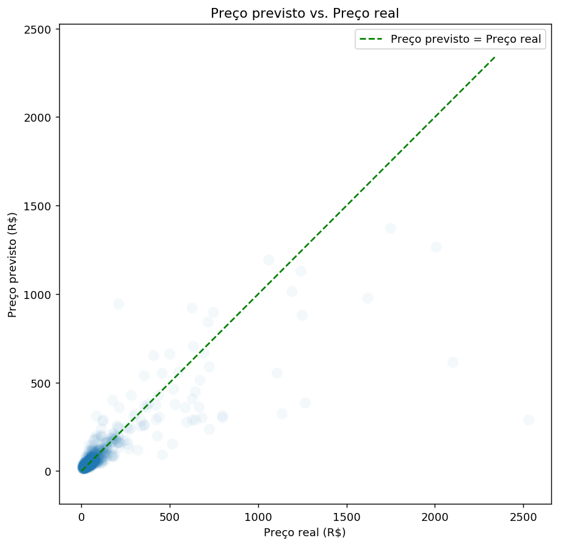

```python
plt.figure(figsize=(8,8), dpi=130)
plt.scatter(test_target, test_predictions, 100, alpha=0.05, edgecolors="none")
baseline = [0, np.max(target)]
plt.plot(baseline, baseline, "--", color="green", label = u"Preço previsto = Preço real")
ax = plt.gca()
ax.set_ylabel(u"Preço previsto (R$)")
ax.set_xlabel(u"Preço real (R$)")
ax.legend()
plt.title(u"Preço previsto vs. Preço real")
plt.axes().set_aspect('equal', 'datalim')
#plt.xlim(0, 150)
#plt.ylim(0, 150)
plt.show()
```

### Mean absolute error

Now we can compare the errors obtained by our predictions against the errors provided by the baseline (average price). Our prediction errors should be less than the baseline errors to consider the model successful.

```python
# Calculate the absolute errors
errors = abs(test_predictions - test_target)
errors_baseline = abs(average_target - test_target)
errors_relative = errors/test_target
errors_baseline_relative = errors_baseline/test_target
# Print out the mean absolute error (mae)
print "== Absolute"
print('Mean absolute prediction error: R$', round(np.mean(errors), 2))
print('Std prediction error: R$', round(np.std(errors), 2))
print('Mean absolute error using average: R$', round(np.mean(errors_baseline), 2))
print('Std prediction error using average: R$', round(np.std(errors_baseline), 2))
print "== Relative"
print('Mean relative absolute prediction error: ', round(np.mean(errors_relative), 2))
print('Std relative prediction error: ', round(np.std(errors_relative), 2))
print('Mean relative absolute error using average: ', round(np.mean(errors_baseline_relative), 2))
print('Std relative prediction error using average: ', round(np.std(errors_baseline_relative), 2))
```

```
== Absolute
('Mean absolute prediction error: R$', 31.4)
('Std prediction error: R$', 113.94)
('Mean absolute error using average: R$', 79.72)
('Std prediction error using average: R$', 183.53)
== Relative
('Mean relative absolute prediction error: ', 0.35)
('Std relative prediction error: ', 0.45)
('Mean relative absolute error using average: ', 1.57)
('Std relative prediction error using average: ', 1.67)
```

### Join data

```python
pd.set_option('display.max_columns', None)
data = {
    "all_features": test_features.tolist(),
    "sha256_id": test_features[:, 0],
    "target": test_target,
    "prediction": test_predictions,
    "error": errors,
    "error_relative": errors_relative,
    "error_baseline": errors_baseline,
    "error_baseline_relative": errors_baseline_relative
}
predicted_df = pd.DataFrame(data = data)
joined_predicted_df = predicted_df
joined_predicted_df = predicted_df.set_index("sha256_id").join(df.set_index("sha256_id"))
```

### Worst absolute predictions

Below we can inspect the rows with the biggest prediction error.

```python
joined_predicted_df.sort_values('error', ascending = False).head(20)
```

| sha256_id | all_features | error | error_baseline | error_baseline_relative | error_relative | prediction | target | id | title | url | authors | coverType | publisher | edition | publicationDate | rankingCategory | category1 | category2 | category3 | category4 | category5 | category6 | category7 | category8 | category9 | category10 | isbn10 | isbn13 | language | … |
| --- | --- | --- | --- | --- | --- | --- | --- | --- | --- | --- | --- | --- | --- | --- | --- | --- | --- | --- | --- | --- | --- | --- | --- | --- | --- | --- | --- | --- | --- | --- |
| 4.565469e+08 | [456546893.0, 13.0, 0.0209756262204, 0.0008169... | 2242.5922 | 2452.113235 | 0.968805 | 0.886025 | 288.4778 | 2531.07 | 1685 | Complex Analysis Complex Analysis Complex Anal... | https://www.amazon.com.br/dp/0070006571/ | Lars V. Ahlfors (Autor), | Capa dura | McGraw-Hill Science/Engineering/Math | NaN | NaN | NaN | NaN | NaN | NaN | NaN | NaN | NaN | NaN | NaN | NaN | NaN | 0070006571 | 978-0070006577 | Inglês | … |
| 1.144179e+09 | [1144179495.0, 4.0, 0.00336963686973, 0.000525... | 1487.3770 | 2022.583235 | 0.962429 | 0.707756 | 614.1630 | 2101.54 | 1991 | Machine Learning | https://www.amazon.com.br/dp/0070428077/ | Tom M. Mitchell (Autor), | Capa dura | McGraw-Hill Science/Engineering/Math | NaN | NaN | NaN | NaN | NaN | NaN | NaN | NaN | NaN | NaN | NaN | NaN | NaN | 0070428077 | 978-0070428072 | Inglês | … |
| 2.611927e+09 | [2611927292.0, 1.0, 0.000829262925663, 0.0, 33... | 881.6258 | 1187.403235 | 0.937651 | 0.696189 | 384.7342 | 1266.36 | 1937 | The Physics of Low-dimensional Semiconductors:... | https://www.amazon.com.br/dp/0521481481/ | Dr John H. Davies (Autor) | Capa dura | Cambridge University Press | NaN | 13 de dezembro de 1997 | NaN | NaN | NaN | NaN | NaN | NaN | NaN | NaN | NaN | NaN | NaN | 0521481481 | 978-0521481489 | Inglês | … |
| 9.187578e+08 | [918757805.0, 13.0, 0.0278900687803, 0.0008335... | 811.4486 | 1056.343235 | 0.930453 | 0.714744 | 323.8514 | 1135.30 | 1789 | An Introduction to Quantum Computing | https://www.amazon.com.br/dp/0198570007/ | Phillip Kaye (Autor), | Capa dura | OUP Oxford | NaN | NaN | Livros | Livros | Inglês e Outras Línguas | Computação, Informática e Mídias Digitais | Hardware | Mainframes e Minicomputadores | NaN | NaN | NaN | NaN | NaN | 0198570007 | 978-0198570004 | Inglês | … |
| 4.056917e+09 | [4056917483.0, 1.0, 0.0010769546258, 0.0, 3392... | 743.0728 | 1928.963235 | 0.960677 | 0.370071 | 1264.8472 | 2007.92 | 1970 | Physics for Scientists and Engineers: A Strate... | https://www.amazon.com.br/dp/0133953149/ | Randall D. Knight (Professor Emeritus) (Autor) | Capa dura | Pearson | NaN | NaN | NaN | NaN | NaN | NaN | NaN | NaN | NaN | NaN | NaN | NaN | NaN | 0133953149 | 978-0133953145 | Inglês | … |
| 2.613017e+09 | [2613017132.0, 2.0, 0.00236167744228, 0.000240... | 734.6534 | 130.473235 | 0.622992 | 3.507871 | 944.0834 | 209.43 | 2024 | Data Structures and Algorithms in Java (2nd Ed... | https://www.amazon.com.br/dp/0672324539/ | Robert Lafore (Autor) | Capa dura | Sams Publishing | NaN | NaN | NaN | NaN | NaN | NaN | NaN | NaN | NaN | NaN | NaN | NaN | NaN | 0672324539 | 978-0672324536 | Inglês | … |
| 8.690354e+08 | [869035427.0, 1.0, 0.00394247323047, 0.0, 3392... | 643.0028 | 1540.853235 | 0.951256 | 0.396962 | 976.8072 | 1619.81 | 2137 | Introduction to Nuclear Engineering (4th Edition) | https://www.amazon.com.br/dp/0134570057/ | John R. Lamarsh (Autor), | Capa dura | Pearson | NaN | NaN | NaN | NaN | NaN | NaN | NaN | NaN | NaN | NaN | NaN | NaN | NaN | 0134570057 | 978-0134570051 | Inglês | … |
| 3.374043e+09 | [3374042526.0, 2.0, 0.00262459959122, 0.000100... | 553.2490 | 1027.653235 | 0.928650 | 0.499949 | 553.3610 | 1106.61 | 1806 | Schrödinger's Killer App: Race to Build the Wo... | https://www.amazon.com.br/dp/1138429619/ | Jonathan P. Dowling (Autor) | NaN | CRC Press | NaN | NaN | NaN | NaN | NaN | NaN | NaN | NaN | NaN | NaN | NaN | NaN | NaN | 1138429619 | 978-1138429611 | Inglês | … |
| 2.111985e+09 | [2111985238.0, 13.0, 0.0302241447492, 0.000394... | 496.8424 | 718.923235 | 0.901042 | 0.622703 | 301.0376 | 797.88 | 2160 | Computational Physics: Problem Solving with Py... | https://www.amazon.com.br/dp/3527413154/ | Rubin H. Landau (Autor), | Capa comum | Wiley VCH | NaN | NaN | NaN | NaN | NaN | NaN | NaN | NaN | NaN | NaN | NaN | NaN | NaN | 3527413154 | 978-3527413157 | Inglês | … |
| 2.497871e+08 | [249787088.0, 15.0, 0.0306939797834, 0.0011727... | 488.7866 | 645.333235 | 0.890987 | 0.674849 | 235.5034 | 724.29 | 1781 | Modern Physics: For Scientists and Engineers | https://www.amazon.com.br/dp/1938787757/ | John Taylor (Autor) | Capa comum | University Science Books | NaN | NaN | NaN | NaN | NaN | NaN | NaN | NaN | NaN | NaN | NaN | NaN | NaN | 1938787757 | 978-1938787751 | Inglês | … |
| 1.065610e+09 | [1065609645.0, 24.0, 0.0527972708832, 0.000621... | 485.3468 | 718.923235 | 0.901042 | 0.608295 | 312.5332 | 797.88 | 1956 | Introducing Einstein's Relativity | https://www.amazon.com.br/dp/0198596863/ | Ray A. D'Inverno (Autor), | Capa comum | Oxford University Press, USA | NaN | 18 de junho de 1992 | NaN | NaN | NaN | NaN | NaN | NaN | NaN | NaN | NaN | NaN | NaN | 0198596863 | 978-0198596868 | Inglês | … |
| 1.654200e+08 | [165419954.0, 2.0, 0.000453549377832, 0.000779... | 382.1362 | 603.513235 | 0.884307 | 0.559931 | 300.3338 | 682.47 | 2174 | Strategic Applications of Named Reactions in O... | https://www.amazon.com.br/dp/0124297854/ | Laszlo Kurti (Autor), | Capa comum | Academic Press | NaN | NaN | Livros | Livros | Inglês e Outras Línguas | Ciências Tecnológicas | Química | Orgânica | NaN | NaN | NaN | NaN | NaN | 0124297854 | 978-0124297852 | Inglês | … |
| 2.082220e+09 | [2082219845.0, 1.0, 0.00116208527541, 0.0, 339... | 376.2774 | 1669.503235 | 0.954842 | 0.215205 | 1372.1826 | 1748.46 | 1706 | Numerical Mathematics and Computing | https://www.amazon.com.br/dp/1133103715/ | E. Ward Cheney (Autor), | Capa dura | Cengage Learning | NaN | NaN | NaN | NaN | NaN | NaN | NaN | NaN | NaN | NaN | NaN | NaN | NaN | 1133103715 | 978-1133103714 | Inglês | … |
| 2.561764e+09 | [2561763589.0, 8.0, 0.014915075102, 0.00021524... | 368.6366 | 1169.983235 | 0.936781 | 0.295160 | 880.3034 | 1248.94 | 1711 | Contemporary Abstract Algebra | https://www.amazon.com.br/dp/1305657969/ | Joseph Gallian (Autor) | Capa dura | Cengage Learning | NaN | NaN | NaN | NaN | NaN | NaN | NaN | NaN | NaN | NaN | NaN | NaN | NaN | 1305657969 | 978-1305657960 | Inglês | … |
| 1.433239e+09 | [1433238979.0, 78.0, 0.0854775965238, 0.019422... | 365.8166 | 378.893235 | 0.827549 | 0.798988 | 92.0334 | 457.85 | 330 | Quantum Computation and Quantum Information | https://www.amazon.com.br/dp/1107002176/ | Michael A. Nielsen (Autor), | NaN | NaN | NaN | NaN | NaN | NaN | NaN | NaN | NaN | NaN | NaN | NaN | NaN | NaN | NaN | NaN | NaN | NaN | … |
| 2.902414e+09 | [2902414236.0, 21.0, 0.0388821107439, 0.000713... | 361.2978 | 435.733235 | 0.846594 | 0.701972 | 153.3922 | 514.69 | 1722 | Analysis on Manifolds | https://www.amazon.com.br/dp/0201315963/ | James R. Munkres (Autor) | Capa comum | Westview Press | NaN | NaN | Livros | Livros | Inglês e Outras Línguas | Ciências Tecnológicas | Matemática | Geometria e Topologia | Geometria Diferencial | NaN | NaN | NaN | NaN | 0201315963 | 978-0201315967 | Inglês | … |
| 2.782673e+08 | [278267321.0, 1.0, 0.000256813937843, 0.0, 339... | 356.6738 | 566.923235 | 0.877753 | 0.552229 | 289.2062 | 645.88 | 2190 | Organic Laboratory Techniques | https://www.amazon.com.br/dp/0534379818/ | Ralph J. Fessenden (Autor), | Capa comum | Cengage Learning | NaN | NaN | NaN | NaN | NaN | NaN | NaN | NaN | NaN | NaN | NaN | NaN | NaN | 0534379818 | 978-0534379810 | Inglês | … |
| 2.450712e+09 | [2450712038.0, 18.0, 0.0287991139451, 0.000931... | 338.3714 | 547.843235 | 0.874032 | 0.539840 | 288.4286 | 626.80 | 1992 | Differential Equations, Dynamical Systems, and... | https://www.amazon.com.br/dp/0123820103/ | Morris W. Hirsch (Autor), | Capa dura | Academic Press | NaN | NaN | Livros | Livros | Inglês e Outras Línguas | Ciências Tecnológicas | Matemática | Aplicada | Equações Diferenciais | NaN | NaN | NaN | NaN | 0123820103 | 978-0123820105 | Inglês | … |
| 7.897180e+08 | [789717993.0, 10.0, 0.0124224355763, 0.0005177... | 320.9248 | 517.173235 | 0.867551 | 0.538347 | 275.2052 | 596.13 | 1838 | Introduction to Mechanics and Symmetry: A Basi... | https://www.amazon.com.br/dp/1441931430/ | Jerrold E. Marsden (Autor), | Capa comum | Springer | NaN | NaN | NaN | NaN | NaN | NaN | NaN | NaN | NaN | NaN | NaN | NaN | NaN | 1441931430 | 978-1441931436 | Inglês | … |
| 3.524441e+09 | [3524440748.0, 2.0, 0.00257870407167, 0.000188... | 304.4552 | 586.653235 | 0.881377 | 0.457408 | 361.1548 | 665.61 | 1923 | Principles of Superconductive Devices and Circ... | https://www.amazon.com.br/dp/0132627426/ | Theodore Van Duzer (Autor), | Capa comum | Prentice Hall | NaN | NaN | NaN | NaN | NaN | NaN | NaN | NaN | NaN | NaN | NaN | NaN | NaN | 0132627426 | 978-0132627429 | Inglês | … |

### Worst relative predictions

```python
joined_predicted_df.sort_values('error_relative', ascending = False).head(20)
```

| sha256_id | all_features | error | error_baseline | error_baseline_relative | error_relative | prediction | target | id | title | url | authors | coverType | publisher | edition | publicationDate | rankingCategory | category1 | category2 | category3 | category4 | category5 | category6 | category7 | category8 | category9 | category10 | isbn10 | isbn13 | language | … |
| --- | --- | --- | --- | --- | --- | --- | --- | --- | --- | --- | --- | --- | --- | --- | --- | --- | --- | --- | --- | --- | --- | --- | --- | --- | --- | --- | --- | --- | --- | --- |
| 2.839318e+08 | [283931800.0, 2.0, 7.37233903426e-05, 0.000147... | 25.5784 | 73.956765 | 14.791353 | 5.115680 | 30.5784 | 5.00 | 4791 | Um Certo Capitão Rodrigo | https://www.amazon.com.br/dp/8535905987/ | Erico Verissimo (Autor) | Capa comum | Companhia das Letras | NaN | NaN | Livros | Livros | Literatura e Ficção | Poesia | Europeia | NaN | NaN | NaN | NaN | NaN | NaN | 8535905987 | 978-8535905984 | Português | … |
| 2.764867e+09 | [2764867435.0, 1.0, 4.71819961072e-06, 0.0, 13... | 37.4110 | 70.576765 | 8.422048 | 4.464320 | 45.7910 | 8.38 | 5112 | Os Filhos do Imperador | https://www.amazon.com.br/dp/8520920594/ | Claire Messud (Autor) | Capa comum | Nova Fronteira | NaN | NaN | Livros | Livros | Romance | NaN | NaN | NaN | NaN | NaN | NaN | NaN | NaN | 8520920594 | 978-8520920596 | Português | … |
| 2.613017e+09 | [2613017132.0, 2.0, 0.00236167744228, 0.000240... | 734.6534 | 130.473235 | 0.622992 | 3.507871 | 944.0834 | 209.43 | 2024 | Data Structures and Algorithms in Java (2nd Ed... | https://www.amazon.com.br/dp/0672324539/ | Robert Lafore (Autor) | Capa dura | Sams Publishing | NaN | NaN | NaN | NaN | NaN | NaN | NaN | NaN | NaN | NaN | NaN | NaN | NaN | 0672324539 | 978-0672324536 | Inglês | … |
| 3.894233e+09 | [3894233020.0, 1.0, 2.11716814285e-05, 0.0, 16... | 20.8622 | 72.966765 | 12.181430 | 3.482838 | 26.8522 | 5.99 | 1408 | Instruções Secretas dos Jesuítas | https://www.amazon.com.br/dp/8573747684/ | Charles Sauvestre (Autor) | Capa comum | Madras | NaN | 5 de fevereiro de 2014 | Livros | Livros | Política, Filosofia e Ciências Sociais | Ciências Sociais | Folclore e Mitologia | NaN | NaN | NaN | NaN | NaN | NaN | 8573747684 | 978-8573747683 | Português | … |
| 3.735809e+09 | [3735808919.0, 1.0, 4.71819961072e-06, 0.0, 20... | 20.3506 | 71.966765 | 10.295675 | 2.911388 | 27.3406 | 6.99 | 5134 | Endgame. O Chamado | https://www.amazon.com.br/dp/8580571863/ | James Frey (Autor), | Capa comum | Intrínseca | NaN | NaN | Livros | Livros | Literatura e Ficção | Ação e Aventura | NaN | NaN | NaN | NaN | NaN | NaN | NaN | 8580571863 | 978-8580571868 | Português | … |
| 4.161038e+09 | [4161037885.0, 4.0, 0.00299665754581, 0.000432... | 226.5634 | 5.373235 | 0.063717 | 2.686629 | 310.8934 | 84.33 | 1854 | The Magic of Math: Solving for x and Figuring ... | https://www.amazon.com.br/dp/0465054722/ | Arthur Benjamin (Autor) | Capa dura | Basic Books | NaN | 8 de setembro de 2015 | Livros | Livros | Inglês e Outras Línguas | Ciências Tecnológicas | Matemática | Estudo e Ensino | NaN | NaN | NaN | NaN | NaN | 0465054722 | 978-0465054725 | Inglês | … |
| 1.167407e+09 | [1167406586.0, 110.0, 0.15770742065, 0.0057148... | 103.2466 | 36.446765 | 0.857369 | 2.428760 | 145.7566 | 42.51 | 350 | Solutions of Exercises of Tensor Calculus Made... | https://www.amazon.com.br/dp/1979870705/ | Taha Sochi (Autor) | Capa comum | Createspace Independent Publishing Platform | NaN | 19 de novembro de 2017 | NaN | NaN | NaN | NaN | NaN | NaN | NaN | NaN | NaN | NaN | NaN | 1979870705 | 978-1979870702 | Inglês | … |
| 2.119922e+09 | [2119922374.0, 4.0, 0.000123960093169, 0.00036... | 53.2232 | 55.256765 | 2.331509 | 2.245705 | 76.9232 | 23.70 | 3887 | Clube Da Luta | https://www.amazon.com.br/dp/8580444497/ | Chuck Palahniuk (Autor), | NaN | NaN | NaN | NaN | NaN | NaN | NaN | NaN | NaN | NaN | NaN | NaN | NaN | NaN | NaN | NaN | NaN | NaN | … |
| 4.263875e+09 | [4263875252.0, 1.0, 3.98529863889e-05, 0.0, 55... | 59.1342 | 51.966765 | 1.925408 | 2.190967 | 86.1242 | 26.99 | 4214 | Frankenstein + O Médico e o Monstro + Drácula | https://www.amazon.com.br/dp/8544001459/ | Mary Shelley (Autor), | Capa dura | Martin Claret | NaN | NaN | Livros | Livros | Literatura e Ficção | Poesia | Europeia | NaN | NaN | NaN | NaN | NaN | NaN | 8544001459 | 978-8544001455 | Português | … |
| 2.505021e+09 | [2505020883.0, 1.0, 1.49040714067e-06, 0.0, 62... | 25.8016 | 66.966765 | 5.585218 | 2.151927 | 37.7916 | 11.99 | 2286 | Big Bang. Como o Mundo Foi Criado | https://www.amazon.com.br/dp/8581301339/ | Julie Andkjaer Olsen (Autor), | Capa dura | Geração | NaN | NaN | Livros | Livros | Infantil | Ciência e Natureza | Ficção | NaN | NaN | NaN | NaN | NaN | NaN | 8581301339 | 978-8581301334 | Português | … |
| 3.687233e+09 | [3687232692.0, 1.0, 1.48970503786e-06, 0.0, 46... | 28.9112 | 64.916765 | 4.623701 | 2.059202 | 42.9512 | 14.04 | 2785 | Pride and Prejudice | https://www.amazon.com.br/dp/0007350775/ | Jane Austen (Autor) | Capa comum | HarperCollins Publishers | NaN | NaN | Livros | Livros | Inglês e Outras Línguas | Literatura e Ficção | Literatura Clássica | NaN | NaN | NaN | NaN | NaN | NaN | 0007350775 | 978-0007350773 | Inglês | … |
| 1.191259e+09 | [1191259498.0, 3.0, 9.57216886263e-05, 0.00043... | 28.6748 | 64.056765 | 4.299112 | 1.924483 | 43.5748 | 14.90 | 3015 | Enquanto Houver Champanhe, Há Esperança | https://www.amazon.com.br/dp/8551000152/ | Joaquim Ferreira dos Santos (Autor) | Capa comum | Intrínseca | NaN | NaN | Livros | Livros | Biografias e Histórias Reais | NaN | NaN | NaN | NaN | NaN | NaN | NaN | NaN | 8551000152 | 978-8551000151 | Português | … |
| 1.641333e+08 | [164133259.0, 1.0, 4.44172292364e-06, 0.0, 650... | 28.2064 | 64.056765 | 4.299112 | 1.893047 | 43.1064 | 14.90 | 4938 | O Código do Caçador de Recompensa | https://www.amazon.com.br/dp/8528614840/ | Daniel Wallace (Autor), | Capa dura | Bertrand | NaN | NaN | Livros | Livros | Literatura e Ficção | NaN | NaN | NaN | NaN | NaN | NaN | NaN | NaN | 8528614840 | 978-8528614848 | Português | … |
| 3.467185e+09 | [3467185181.0, 2.0, 6.09572831251e-06, 8.96776... | 13.1244 | 71.966765 | 10.295675 | 1.877597 | 20.1144 | 6.99 | 4735 | Ansiedade. Como Enfrentar o Mal do Século. Par... | https://www.amazon.com.br/dp/8582402104/ | Augusto Cury (Autor) | Capa comum | Saraiva | NaN | NaN | Livros | Livros | Autoajuda | NaN | NaN | NaN | NaN | NaN | NaN | NaN | NaN | 8582402104 | 978-8582402108 | Português | … |
| 3.788238e+09 | [3788238094.0, 2.0, 1.8099916179e-05, 0.000586... | 12.9996 | 71.966765 | 10.295675 | 1.859742 | 19.9896 | 6.99 | 5225 | Escrita. Uma Breve Introdução. Pocket Encyclop... | https://www.amazon.com.br/dp/8525428248/ | Andrew Robinson (Autor), | Livro de bolso | L&PM | NaN | NaN | Livros | Livros | História | Mundial | Civilização e Cultura | NaN | NaN | NaN | NaN | NaN | NaN | 8525428248 | 978-8525428240 | Português | … |
| 3.048972e+09 | [3048972352.0, 4.0, 0.000372312629527, 0.00058... | 12.7040 | 71.966765 | 10.295675 | 1.817454 | 19.6940 | 6.99 | 5529 | A Fera na Selva - Coleção Novelas Imortais | https://www.amazon.com.br/dp/8579800730/ | Henry James (Autor) | Capa comum | Rocco | NaN | NaN | Livros | Livros | Literatura e Ficção | Ficção | NaN | NaN | NaN | NaN | NaN | NaN | NaN | 8579800730 | 978-8579800733 | Português | … |
| 3.732908e+07 | [37329082.0, 1.0, 2.93577690918e-05, 0.0, 1561... | 30.8308 | 61.906765 | 3.630895 | 1.808258 | 47.8808 | 17.05 | 3591 | O Super-Homem Vai Ao Supermercado | https://www.amazon.com.br/dp/8535908986/ | Norman Mailer (Autor) | Capa comum | Companhia das Letras | NaN | NaN | Livros | Livros | Educação, Referência e Didáticos | Guias de Escrita, Pesquisa e Publicação | Jornalismo | NaN | NaN | NaN | NaN | NaN | NaN | 8535908986 | 978-8535908985 | Português | … |
| 3.414252e+09 | [3414252235.0, 4.0, 1.44532258229e-05, 0.00062... | 72.5294 | 37.056765 | 0.884410 | 1.731012 | 114.4294 | 41.90 | 2383 | Manual Prático do Corpo Sutil | https://www.amazon.com.br/dp/8531613922/ | Cyndi Dale (Autor), | Capa comum | Cultrix | NaN | NaN | Livros | Livros | Saúde e Família | NaN | NaN | NaN | NaN | NaN | NaN | NaN | NaN | 8531613922 | 978-8531613920 | Português | … |
| 1.908710e+09 | [1908709709.0, 1.0, 3.62307641249e-06, 0.0, 52... | 25.5424 | 63.956765 | 4.263784 | 1.702827 | 40.5424 | 15.00 | 3671 | Heidegger | https://www.amazon.com.br/dp/8515044234/ | Benedito Nunes (Autor) | Capa comum | Loyola | NaN | NaN | Livros | Livros | Religião e Espiritualidade | NaN | NaN | NaN | NaN | NaN | NaN | NaN | NaN | 8515044234 | 978-8515044238 | Português | … |
| 2.701224e+08 | [270122440.0, 1.0, 3.62307641249e-06, 0.0, 420... | 28.8662 | 61.976765 | 3.649986 | 1.700012 | 45.8462 | 16.98 | 5538 | As Excelências do Governador | https://www.amazon.com.br/dp/8535902252/ | Stuart B. Schwartz (Autor), | Capa comum | Companhia das Letras | NaN | NaN | Livros | Livros | História | Américas | América Latina | Brasil | NaN | NaN | NaN | NaN | NaN | 8535902252 | 978-8535902259 | Português | … |

### Best absolute predictions

```python
joined_predicted_df.sort_values('error', ascending = True).head(20)
```

| sha256_id | all_features | error | error_baseline | error_baseline_relative | error_relative | prediction | target | id | title | url | authors | coverType | publisher | edition | publicationDate | rankingCategory | category1 | category2 | category3 | category4 | category5 | category6 | category7 | category8 | category9 | category10 | isbn10 | isbn13 | language | … |
| --- | --- | --- | --- | --- | --- | --- | --- | --- | --- | --- | --- | --- | --- | --- | --- | --- | --- | --- | --- | --- | --- | --- | --- | --- | --- | --- | --- | --- | --- | --- |
| 2.926372e+09 | [2926372007.0, 1.0, 8.97530683752e-05, 0.0, 44... | 0.0066 | 54.056765 | 2.170954 | 0.000265 | 24.8934 | 24.90 | 3748 | As Moscas | https://www.amazon.com.br/dp/8520917569/ | Jean-Paul Sartre (Autor) | Capa comum | Nova Fronteira | NaN | 16 de dezembro de 2013 | Livros | Livros | Arte, Cinema e Fotografia | Teatro | NaN | NaN | NaN | NaN | NaN | NaN | NaN | 8520917569 | 978-8520917565 | Português | … |
| 4.114357e+09 | [4114356949.0, 1.0, 1.01857966741e-05, 0.0, 89... | 0.0184 | 46.776765 | 1.453597 | 0.000572 | 32.1984 | 32.18 | 5242 | Contra o Aborto | https://www.amazon.com.br/dp/8501110213/ | Francisco Razzo (Autor) | Capa comum | Record | NaN | NaN | Livros | Livros | Política, Filosofia e Ciências Sociais | Ciências Sociais | NaN | NaN | NaN | NaN | NaN | NaN | NaN | 8501110213 | 978-8501110213 | Português | … |
| 8.790173e+08 | [879017256.0, 1.0, 1.95141797512e-05, 0.0, 273... | 0.0226 | 51.496765 | 1.875337 | 0.000823 | 27.4826 | 27.46 | 5188 | A Rebelde do Deserto | https://www.amazon.com.br/dp/8565765997/ | Alwyn Hamilton (Autor) | Capa comum | Seguinte | NaN | NaN | Livros | Livros | Literatura e Ficção | Literatura Infantojuvenil | NaN | NaN | NaN | NaN | NaN | NaN | NaN | 8565765997 | 978-8565765992 | Português | … |
| 4.059001e+09 | [4059001319.0, 4.0, 1.03095669322e-05, 0.00011... | 0.0454 | 56.056765 | 2.447894 | 0.001983 | 22.9454 | 22.90 | 4732 | De Volta a Cabana | https://www.amazon.com.br/dp/8575426982/ | C. Baxter Kruger (Autor) | Capa comum | Sextante | NaN | NaN | Livros | Livros | Autoajuda | NaN | NaN | NaN | NaN | NaN | NaN | NaN | NaN | 8575426982 | 978-8575426982 | Português | … |
| 2.616471e+09 | [2616471371.0, 2.0, 5.72701328447e-06, 0.00050... | 0.0472 | 39.056765 | 0.978866 | 0.001183 | 39.8528 | 39.90 | 2300 | O Homem e Seus Símbolos | https://www.amazon.com.br/dp/8569809638/ | Carl G. Jung (Autor) | Capa comum | HarperCollins Brasil | NaN | NaN | Livros | Livros | Saúde e Família | Psicologia e Aconselhamento | NaN | NaN | NaN | NaN | NaN | NaN | NaN | 8569809638 | 978-8569809630 | Português | … |
| 1.205878e+09 | [1205877744.0, 1.0, 2.48019152419e-05, 0.0, 29... | 0.0598 | 31.776765 | 0.673522 | 0.001267 | 47.2398 | 47.18 | 2865 | Brevíssima História De Quase Tudo | https://www.amazon.com.br/dp/8574064165/ | Bill Bryson (Autor) | Capa comum | Companhia das Letrinhas | NaN | NaN | Livros | Livros | Infantil | Ciência e Natureza | Ficção | NaN | NaN | NaN | NaN | NaN | NaN | 8574064165 | 978-8574064161 | Português | … |
| 1.632954e+09 | [1632953594.0, 1.0, 5.28232504039e-06, 0.0, 21... | 0.0734 | 55.056765 | 2.303630 | 0.003071 | 23.8266 | 23.90 | 3294 | O Sabor Da Harmonia. Receitas Ayurvédicas Para... | https://www.amazon.com.br/dp/8532528678/ | Laura Pires (Autor) | Capa comum | Rocco | NaN | NaN | Livros | Livros | Saúde e Família | Dietas e Emagrecimento | Dietas | NaN | NaN | NaN | NaN | NaN | NaN | 8532528678 | 978-8532528674 | Português | … |
| 1.546931e+09 | [1546931111.0, 1.0, 1.35635410926e-06, 0.0, 65... | 0.0940 | 22.943235 | 0.225154 | 0.000922 | 101.8060 | 101.90 | 824 | Descobrindo a Estatística Utilizando o SPSS | https://www.amazon.com.br/dp/8536319275/ | Andy Field (Autor) | Capa comum | Penso | NaN | NaN | Livros | Livros | Ciências | Educação | Pesquisa | NaN | NaN | NaN | NaN | NaN | NaN | 8536319275 | 978-8536319278 | Português | … |
| 1.439901e+08 | [143990078.0, 1.0, 5.28232504039e-06, 0.0, 513... | 0.1018 | 51.456765 | 1.871155 | 0.003702 | 27.6018 | 27.50 | 3317 | Lugar de Medico e na Cozinha. Cura e Saúde Pel... | https://www.amazon.com.br/dp/8578810023/ | Dr. Alberto Peribanez Gonzalez (Autor) | Capa comum | Alaúde | NaN | NaN | Livros | Livros | Saúde e Família | Nutrição | NaN | NaN | NaN | NaN | NaN | NaN | NaN | 8578810023 | 978-8578810023 | Português | … |
| 1.351796e+09 | [1351795579.0, 56.0, 0.00176390982186, 0.02251... | 0.1054 | 51.296765 | 1.854547 | 0.003811 | 27.7654 | 27.66 | 418 | Bilhões e Bilhões | https://www.amazon.com.br/dp/8535911944/ | Carl Sagan (Autor) | Capa comum | Companhia de Bolso | NaN | NaN | Livros | Livros | Ciências | Ensaios e Comentários | NaN | NaN | NaN | NaN | NaN | NaN | NaN | 8535911944 | 978-8535911947 | Português | … |
| 1.496393e+08 | [149639295.0, 4.0, 1.86907784783e-05, 0.000445... | 0.1150 | 60.156765 | 3.199828 | 0.006117 | 18.9150 | 18.80 | 2295 | Intuição. O Saber Além da Lógica | https://www.amazon.com.br/dp/8531607825/ | Osho International Foundation (Arranjo por) | Capa comum | Cultrix | NaN | NaN | Livros | Livros | Autoajuda | Transformação Pessoal | NaN | NaN | NaN | NaN | NaN | NaN | NaN | 8531607825 | 978-8531607820 | Português | … |
| 2.031627e+09 | [2031627486.0, 5.0, 5.81830057454e-05, 0.00107... | 0.1174 | 51.896765 | 1.917841 | 0.004339 | 27.1774 | 27.06 | 2760 | Genética: Escolhas que nossos avós não faziam | https://www.amazon.com.br/dp/8525050342/ | Mayana Zatz (Autor) | Capa comum | Globo Livros | NaN | NaN | Livros | Livros | Literatura e Ficção | Ensaios e Correspondências | NaN | NaN | NaN | NaN | NaN | NaN | NaN | 8525050342 | 978-8525050342 | Português | … |
| 2.662359e+09 | [2662359335.0, 4.0, 6.68460326175e-05, 0.00099... | 0.1284 | 57.156765 | 2.621870 | 0.005890 | 21.6716 | 21.80 | 3278 | Berlim 1945, a Queda - Volume 1 | https://www.amazon.com.br/dp/8577994759/ | Antony Beevor (Autor), | Capa comum | Best Bolso | NaN | NaN | Livros | Livros | História | NaN | NaN | NaN | NaN | NaN | NaN | NaN | NaN | 8577994759 | 978-8577994755 | Português | … |
| 3.969474e+09 | [3969473513.0, 4.0, 7.51771052665e-05, 0.00210... | 0.1290 | 55.056765 | 2.303630 | 0.005397 | 23.7710 | 23.90 | 3615 | Blink. A Decisão Num Piscar de Olhos | https://www.amazon.com.br/dp/8543103592/ | Malcolm Gladwell (Autor) | Capa comum | Sextante | NaN | NaN | Livros | Livros | Saúde e Família | Psicologia e Aconselhamento | NaN | NaN | NaN | NaN | NaN | NaN | NaN | 8543103592 | 978-8543103594 | Português | … |
| 2.966188e+09 | [2966188146.0, 1.0, 3.27923676645e-06, 0.0, 55... | 0.1376 | 56.556765 | 2.524856 | 0.006143 | 22.5376 | 22.40 | 5014 | Ferreiro de Bosque Grande | https://www.amazon.com.br/dp/8546900035/ | J.R.R. Tolkien (Autor), | Capa comum | WMF Martins Fontes | NaN | NaN | Livros | Livros | Infantil | Contos de Fadas , Contos Populares e Mitos | Antologias | NaN | NaN | NaN | NaN | NaN | NaN | 8546900035 | 978-8546900039 | Português | … |
| 1.561973e+09 | [1561973287.0, 3.0, 4.43264160591e-05, 0.00030... | 0.1418 | 43.056765 | 1.199353 | 0.003950 | 35.7582 | 35.90 | 4251 | Gigantes Adormecidos | https://www.amazon.com.br/dp/8556510124/ | Sylvain Neuvel (Autor) | Capa comum | Suma de Letras | NaN | NaN | Livros | Livros | Literatura e Ficção | NaN | NaN | NaN | NaN | NaN | NaN | NaN | NaN | 8556510124 | 978-8556510129 | Português | … |
| 2.911873e+09 | [2911873299.0, 5.0, 7.52103768378e-05, 0.00077... | 0.1452 | 52.056765 | 1.935196 | 0.005398 | 27.0452 | 26.90 | 941 | Tio Petros e a Conjectura de Goldbach | https://www.amazon.com.br/dp/8573261978/ | Apostolos Doxiadis (Autor) | Capa comum | Editora 34 | NaN | NaN | Livros | Livros | Literatura e Ficção | Literatura Infantojuvenil | NaN | NaN | NaN | NaN | NaN | NaN | NaN | 8573261978 | 978-8573261974 | Português | … |
| 3.194220e+09 | [3194219723.0, 4.0, 0.000159900962194, 0.00033... | 0.1886 | 51.056765 | 1.829992 | 0.006760 | 27.7114 | 27.90 | 3852 | O Ódio que Você Semeia | https://www.amazon.com.br/dp/8501110817/ | Angie Thomas (Autor) | Capa comum | Galera Record | NaN | NaN | Livros | Livros | Romance | NaN | NaN | NaN | NaN | NaN | NaN | NaN | NaN | 8501110817 | 978-8501110817 | Português | … |
| 1.688503e+09 | [1688502809.0, 1.0, 5.50478678551e-05, 0.0, 25... | 0.1902 | 36.876765 | 0.876349 | 0.004520 | 41.8898 | 42.08 | 4381 | Nora Webster | https://www.amazon.com.br/dp/8535925953/ | Colm Tóibín (Autor) | Capa comum | Companhia das Letras | NaN | NaN | Livros | Livros | Romance | NaN | NaN | NaN | NaN | NaN | NaN | NaN | NaN | 8535925953 | 978-8535925951 | Português | … |
| 1.171374e+09 | [1171373908.0, 2.0, 0.000147676862584, 0.00052... | 0.2152 | 55.666765 | 2.390157 | 0.009240 | 23.5052 | 23.29 | 3622 | Moneyball. O Homem que Mudou o Jogo | https://www.amazon.com.br/dp/8580577349/ | Michael Lewis (Autor) | Capa comum | Intrínseca | NaN | NaN | Livros | Livros | Biografias e Histórias Reais | NaN | NaN | NaN | NaN | NaN | NaN | NaN | NaN | 8580577349 | 978-8580577341 | Português | … |

```python
joined_predicted_df.sort_values('error', ascending = True).head(20)
```

| sha256_id | all_features | error | error_baseline | error_baseline_relative | error_relative | prediction | target | id | title | url | authors | coverType | publisher | edition | publicationDate | rankingCategory | category1 | category2 | category3 | category4 | category5 | category6 | category7 | category8 | category9 | category10 | isbn10 | isbn13 | language | … |
| --- | --- | --- | --- | --- | --- | --- | --- | --- | --- | --- | --- | --- | --- | --- | --- | --- | --- | --- | --- | --- | --- | --- | --- | --- | --- | --- | --- | --- | --- | --- |
| 2.926372e+09 | [2926372007.0, 1.0, 8.97530683752e-05, 0.0, 44... | 0.0066 | 54.056765 | 2.170954 | 0.000265 | 24.8934 | 24.90 | 3748 | As Moscas | https://www.amazon.com.br/dp/8520917569/ | Jean-Paul Sartre (Autor) | Capa comum | Nova Fronteira | NaN | 16 de dezembro de 2013 | Livros | Livros | Arte, Cinema e Fotografia | Teatro | NaN | NaN | NaN | NaN | NaN | NaN | NaN | 8520917569 | 978-8520917565 | Português | … |
| 4.114357e+09 | [4114356949.0, 1.0, 1.01857966741e-05, 0.0, 89... | 0.0184 | 46.776765 | 1.453597 | 0.000572 | 32.1984 | 32.18 | 5242 | Contra o Aborto | https://www.amazon.com.br/dp/8501110213/ | Francisco Razzo (Autor) | Capa comum | Record | NaN | NaN | Livros | Livros | Política, Filosofia e Ciências Sociais | Ciências Sociais | NaN | NaN | NaN | NaN | NaN | NaN | NaN | 8501110213 | 978-8501110213 | Português | … |
| 8.790173e+08 | [879017256.0, 1.0, 1.95141797512e-05, 0.0, 273... | 0.0226 | 51.496765 | 1.875337 | 0.000823 | 27.4826 | 27.46 | 5188 | A Rebelde do Deserto | https://www.amazon.com.br/dp/8565765997/ | Alwyn Hamilton (Autor) | Capa comum | Seguinte | NaN | NaN | Livros | Livros | Literatura e Ficção | Literatura Infantojuvenil | NaN | NaN | NaN | NaN | NaN | NaN | NaN | 8565765997 | 978-8565765992 | Português | … |
| 4.059001e+09 | [4059001319.0, 4.0, 1.03095669322e-05, 0.00011... | 0.0454 | 56.056765 | 2.447894 | 0.001983 | 22.9454 | 22.90 | 4732 | De Volta a Cabana | https://www.amazon.com.br/dp/8575426982/ | C. Baxter Kruger (Autor) | Capa comum | Sextante | NaN | NaN | Livros | Livros | Autoajuda | NaN | NaN | NaN | NaN | NaN | NaN | NaN | NaN | 8575426982 | 978-8575426982 | Português | … |
| 2.616471e+09 | [2616471371.0, 2.0, 5.72701328447e-06, 0.00050... | 0.0472 | 39.056765 | 0.978866 | 0.001183 | 39.8528 | 39.90 | 2300 | O Homem e Seus Símbolos | https://www.amazon.com.br/dp/8569809638/ | Carl G. Jung (Autor) | Capa comum | HarperCollins Brasil | NaN | NaN | Livros | Livros | Saúde e Família | Psicologia e Aconselhamento | NaN | NaN | NaN | NaN | NaN | NaN | NaN | 8569809638 | 978-8569809630 | Português | … |
| 1.205878e+09 | [1205877744.0, 1.0, 2.48019152419e-05, 0.0, 29... | 0.0598 | 31.776765 | 0.673522 | 0.001267 | 47.2398 | 47.18 | 2865 | Brevíssima História De Quase Tudo | https://www.amazon.com.br/dp/8574064165/ | Bill Bryson (Autor) | Capa comum | Companhia das Letrinhas | NaN | NaN | Livros | Livros | Infantil | Ciência e Natureza | Ficção | NaN | NaN | NaN | NaN | NaN | NaN | 8574064165 | 978-8574064161 | Português | … |
| 1.632954e+09 | [1632953594.0, 1.0, 5.28232504039e-06, 0.0, 21... | 0.0734 | 55.056765 | 2.303630 | 0.003071 | 23.8266 | 23.90 | 3294 | O Sabor Da Harmonia. Receitas Ayurvédicas Para... | https://www.amazon.com.br/dp/8532528678/ | Laura Pires (Autor) | Capa comum | Rocco | NaN | NaN | Livros | Livros | Saúde e Família | Dietas e Emagrecimento | Dietas | NaN | NaN | NaN | NaN | NaN | NaN | 8532528678 | 978-8532528674 | Português | … |
| 1.546931e+09 | [1546931111.0, 1.0, 1.35635410926e-06, 0.0, 65... | 0.0940 | 22.943235 | 0.225154 | 0.000922 | 101.8060 | 101.90 | 824 | Descobrindo a Estatística Utilizando o SPSS | https://www.amazon.com.br/dp/8536319275/ | Andy Field (Autor) | Capa comum | Penso | NaN | NaN | Livros | Livros | Ciências | Educação | Pesquisa | NaN | NaN | NaN | NaN | NaN | NaN | 8536319275 | 978-8536319278 | Português | … |
| 1.439901e+08 | [143990078.0, 1.0, 5.28232504039e-06, 0.0, 513... | 0.1018 | 51.456765 | 1.871155 | 0.003702 | 27.6018 | 27.50 | 3317 | Lugar de Medico e na Cozinha. Cura e Saúde Pel... | https://www.amazon.com.br/dp/8578810023/ | Dr. Alberto Peribanez Gonzalez (Autor) | Capa comum | Alaúde | NaN | NaN | Livros | Livros | Saúde e Família | Nutrição | NaN | NaN | NaN | NaN | NaN | NaN | NaN | 8578810023 | 978-8578810023 | Português | … |
| 1.351796e+09 | [1351795579.0, 56.0, 0.00176390982186, 0.02251... | 0.1054 | 51.296765 | 1.854547 | 0.003811 | 27.7654 | 27.66 | 418 | Bilhões e Bilhões | https://www.amazon.com.br/dp/8535911944/ | Carl Sagan (Autor) | Capa comum | Companhia de Bolso | NaN | NaN | Livros | Livros | Ciências | Ensaios e Comentários | NaN | NaN | NaN | NaN | NaN | NaN | NaN | 8535911944 | 978-8535911947 | Português | … |
| 1.496393e+08 | [149639295.0, 4.0, 1.86907784783e-05, 0.000445... | 0.1150 | 60.156765 | 3.199828 | 0.006117 | 18.9150 | 18.80 | 2295 | Intuição. O Saber Além da Lógica | https://www.amazon.com.br/dp/8531607825/ | Osho International Foundation (Arranjo por) | Capa comum | Cultrix | NaN | NaN | Livros | Livros | Autoajuda | Transformação Pessoal | NaN | NaN | NaN | NaN | NaN | NaN | NaN | 8531607825 | 978-8531607820 | Português | … |
| 2.031627e+09 | [2031627486.0, 5.0, 5.81830057454e-05, 0.00107... | 0.1174 | 51.896765 | 1.917841 | 0.004339 | 27.1774 | 27.06 | 2760 | Genética: Escolhas que nossos avós não faziam | https://www.amazon.com.br/dp/8525050342/ | Mayana Zatz (Autor) | Capa comum | Globo Livros | NaN | NaN | Livros | Livros | Literatura e Ficção | Ensaios e Correspondências | NaN | NaN | NaN | NaN | NaN | NaN | NaN | 8525050342 | 978-8525050342 | Português | … |
| 2.662359e+09 | [2662359335.0, 4.0, 6.68460326175e-05, 0.00099... | 0.1284 | 57.156765 | 2.621870 | 0.005890 | 21.6716 | 21.80 | 3278 | Berlim 1945, a Queda - Volume 1 | https://www.amazon.com.br/dp/8577994759/ | Antony Beevor (Autor), | Capa comum | Best Bolso | NaN | NaN | Livros | Livros | História | NaN | NaN | NaN | NaN | NaN | NaN | NaN | NaN | 8577994759 | 978-8577994755 | Português | … |
| 3.969474e+09 | [3969473513.0, 4.0, 7.51771052665e-05, 0.00210... | 0.1290 | 55.056765 | 2.303630 | 0.005397 | 23.7710 | 23.90 | 3615 | Blink. A Decisão Num Piscar de Olhos | https://www.amazon.com.br/dp/8543103592/ | Malcolm Gladwell (Autor) | Capa comum | Sextante | NaN | NaN | Livros | Livros | Saúde e Família | Psicologia e Aconselhamento | NaN | NaN | NaN | NaN | NaN | NaN | NaN | 8543103592 | 978-8543103594 | Português | … |
| 2.966188e+09 | [2966188146.0, 1.0, 3.27923676645e-06, 0.0, 55... | 0.1376 | 56.556765 | 2.524856 | 0.006143 | 22.5376 | 22.40 | 5014 | Ferreiro de Bosque Grande | https://www.amazon.com.br/dp/8546900035/ | J.R.R. Tolkien (Autor), | Capa comum | WMF Martins Fontes | NaN | NaN | Livros | Livros | Infantil | Contos de Fadas , Contos Populares e Mitos | Antologias | NaN | NaN | NaN | NaN | NaN | NaN | 8546900035 | 978-8546900039 | Português | … |
| 1.561973e+09 | [1561973287.0, 3.0, 4.43264160591e-05, 0.00030... | 0.1418 | 43.056765 | 1.199353 | 0.003950 | 35.7582 | 35.90 | 4251 | Gigantes Adormecidos | https://www.amazon.com.br/dp/8556510124/ | Sylvain Neuvel (Autor) | Capa comum | Suma de Letras | NaN | NaN | Livros | Livros | Literatura e Ficção | NaN | NaN | NaN | NaN | NaN | NaN | NaN | NaN | 8556510124 | 978-8556510129 | Português | … |
| 2.911873e+09 | [2911873299.0, 5.0, 7.52103768378e-05, 0.00077... | 0.1452 | 52.056765 | 1.935196 | 0.005398 | 27.0452 | 26.90 | 941 | Tio Petros e a Conjectura de Goldbach | https://www.amazon.com.br/dp/8573261978/ | Apostolos Doxiadis (Autor) | Capa comum | Editora 34 | NaN | NaN | Livros | Livros | Literatura e Ficção | Literatura Infantojuvenil | NaN | NaN | NaN | NaN | NaN | NaN | NaN | 8573261978 | 978-8573261974 | Português | … |
| 3.194220e+09 | [3194219723.0, 4.0, 0.000159900962194, 0.00033... | 0.1886 | 51.056765 | 1.829992 | 0.006760 | 27.7114 | 27.90 | 3852 | O Ódio que Você Semeia | https://www.amazon.com.br/dp/8501110817/ | Angie Thomas (Autor) | Capa comum | Galera Record | NaN | NaN | Livros | Livros | Romance | NaN | NaN | NaN | NaN | NaN | NaN | NaN | NaN | 8501110817 | 978-8501110817 | Português | … |
| 1.688503e+09 | [1688502809.0, 1.0, 5.50478678551e-05, 0.0, 25... | 0.1902 | 36.876765 | 0.876349 | 0.004520 | 41.8898 | 42.08 | 4381 | Nora Webster | https://www.amazon.com.br/dp/8535925953/ | Colm Tóibín (Autor) | Capa comum | Companhia das Letras | NaN | NaN | Livros | Livros | Romance | NaN | NaN | NaN | NaN | NaN | NaN | NaN | NaN | 8535925953 | 978-8535925951 | Português | … |
| 1.171374e+09 | [1171373908.0, 2.0, 0.000147676862584, 0.00052... | 0.2152 | 55.666765 | 2.390157 | 0.009240 | 23.5052 | 23.29 | 3622 | Moneyball. O Homem que Mudou o Jogo | https://www.amazon.com.br/dp/8580577349/ | Michael Lewis (Autor) | Capa comum | Intrínseca | NaN | NaN | Livros | Livros | Biografias e Histórias Reais | NaN | NaN | NaN | NaN | NaN | NaN | NaN | NaN | 8580577349 | 978-8580577341 | Português | … |

### Relative errors distribution

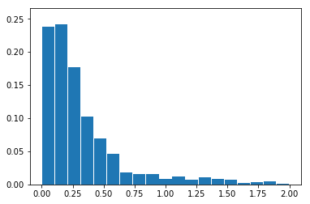

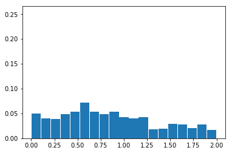

```python
count = len(predicted_df.error_relative)
hist_predicted = np.histogram(predicted_df.error_relative, np.linspace(0, 2, 20))
normalized_hist_predicted = hist_predicted[0]/count
hist_baseline = np.histogram(predicted_df.error_baseline_relative, np.linspace(0, 2, 20))
normalized_hist_baseline = hist_baseline[0]/count
centers = np.convolve(hist_predicted[1], [0.5, 0.5])
centers = centers[1:-1]
plt.bar(centers, normalized_hist_predicted, width=(centers[1]-centers[0])*0.95)
ylim = max(hist_predicted[0]/count) * 1.1
plt.ylim(0, ylim)
plt.show()
plt.bar(centers, normalized_hist_baseline, width=(centers[1]-centers[0])*0.95)
plt.ylim(0, ylim)
plt.show()
```

#### Accumulated

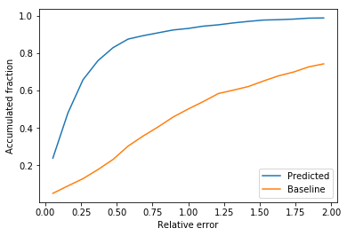

```python
def accumulated_distribution(histogram):
    accumulated = []
    total = 0
    for value in histogram:
        total += value
        accumulated.append(total)
    return accumulated


plt.plot(centers, accumulated_distribution(normalized_hist_predicted), label='Predicted')
plt.plot(centers, accumulated_distribution(normalized_hist_baseline), label='Baseline')
plt.xlabel('Relative error')
plt.ylabel('Accumulated fraction')
plt.legend(loc='lower right')
plt.show()
```

### Joined data summary

```python
predicted_df.describe(percentiles=[0.25, 0.5, 0.75, 0.85, 0.9, 0.95, 0.99])
```

|  | error | error_baseline | error_baseline_relative | error_relative | prediction | sha256_id | target |
| --- | --- | --- | --- | --- | --- | --- | --- |
| count | 981.000000 | 981.000000 | 981.000000 | 981.000000 | 981.000000 | 9.810000e+02 | 981.000000 |
| mean | 31.396329 | 79.718584 | 1.567475 | 0.350313 | 78.329819 | 2.133335e+09 | 88.884016 |
| std | 113.999953 | 183.626277 | 1.667192 | 0.452830 | 135.825123 | 1.239867e+09 | 199.953734 |
| min | 0.006600 | 0.056765 | 0.000719 | 0.000265 | 12.054800 | 1.379265e+06 | 4.990000 |
| 25% | 4.063800 | 32.056765 | 0.555123 | 0.110179 | 28.865800 | 1.047506e+09 | 25.900000 |
| 50% | 9.193600 | 46.946765 | 1.050825 | 0.217640 | 37.791600 | 2.145882e+09 | 38.500000 |
| 75% | 18.875800 | 58.356765 | 2.048524 | 0.406923 | 61.793600 | 3.179767e+09 | 62.000000 |
| 85% | 29.872800 | 64.966765 | 2.777836 | 0.560502 | 102.711400 | 3.687233e+09 | 99.720000 |
| 90% | 51.015800 | 73.063235 | 3.388925 | 0.783967 | 157.318000 | 3.891964e+09 | 146.880000 |
| 95% | 107.325800 | 260.203235 | 4.643800 | 1.252760 | 288.428600 | 4.064086e+09 | 339.160000 |
| 99% | 486.034760 | 1033.391235 | 7.871547 | 2.077747 | 849.572360 | 4.238689e+09 | 1112.348000 |
| max | 2242.592200 | 2452.113235 | 14.822999 | 5.115680 | 1372.182600 | 4.292174e+09 | 2531.070000 |

### Visualize decision tree

```python
# Pull out one tree from the forest
tree = rf.estimators_[0]
# Export the image to a dot file
export_graphviz(tree, out_file = 'tree.dot',
                feature_names = feature_list, rounded = True)
# Use dot file to create a graph
(graph, ) = pydot.graph_from_dot_file('tree.dot')
# Write graph to a png file
graph.write_png('tree.png')
```

[figure not shown]